## 자동 탐색적 데이터 분석

데이터 분석을 하기 위해서 가장 먼저 해야하는 작업은 분석에 필요한 적절한 데이터를 찾고 얻어내는 것일 것이다. 자신이 분석하기 원하는 데이터를 찾았다면 먼저 데이터를 R로 불러들여야 한다. 이 작업이 끝나면 이제 본격적으로 데이터 분석을 시작해야 한다.

그렇다면 이제 무슨 작업을 해야하는 것일까?

우선은 자신이 불러들인 데이터가 어떻게 생겼고 어떤 특성을 지녔는지 전반적으로 확인해야 할 것이다. 이 작업을 탐색적 데이터 분석( Exploratory Data Analysis : EDA)이라고 한다.

대부분의 R 관련 입문 도서들에서는 탐색적 데이터 분석을 위해 `head()`와 `tail()`로 개략적인 데이터를 확인하고 `str()`과 `glimpse()`를 사용하여 데이터프레임의 전반적인 구조를 확인하는 방법을 소개한다. 하지만 R에서는 이보다 강력한 EDA 패키지가 제공된다. 이번 포스트에서는 다양한 EDA 패키지에 대해 소개한다.

EDA 패키지의 기능을 소개하기 위해 사용하는 데이터는 ‘평균과 중간값 등 통계치의 시각화 in R’(https://2stndard.tistory.com/132) 포스트에서 사용했던 데이터를 사용하도록 하겠다.

```r
df_dropout <- read_excel('데이터저장폴더/유초 주요-04 시도별 행정구역별 교육통계 현황_방통제외(1999-2022)_20220824y.xlsx',
           sheet = '2021-2022',
           skip = 11,
           col_names = FALSE,
           col_types = c(rep('text', 4), rep('numeric', 166)))

df_dropout <- df_dropout |>
  select(1, 2, 3, 4, 22, seq(from = 127, to = 142, by = 3)) |>
  rename(c('연도' = ...1, '시도' = ...2, '시군' = ...3, '학교급' = ...4, '전체학생수' = ...22, '학업중단자' = ...127, '유예' = ...130, '면제' = ...133, '자퇴' = ...136, '퇴학' = ...139, '제적' = ...142))
```

여기에 일부 열을 팩터로 변경하여 사용한다.

```r
df_dropout <- df_dropout  |>
  mutate(시도 = as.factor(시도),
         학교급 = as.factor(학교급))
```

### SmartEDA 패키지

`SmartEDA` 패키지는 데이터프레임의 구조와 관계를 설명하는 다양한 함수를 제공한다. 특히 그래트와 차트를 통해 EDA를 제공하고 EDA를 종합한 보고서도 작성할 수 있다는 장점이 있다.

우선 `SmartEDA` 패키지를 설치한다.

```r
if (!require(SmartEDA)) {
  install.packages('SmartEDA')
  library(SmartEDA)
}
```

### 전체 데이터 요약

`SmartEDA`에서 가장 기본적으로 사용되는 함수는 `ExpData()`이다. 이 함수는 데이터프레임의 전반적인 개요를 설명해주는 메타데이터와 데이터들의 종합값을 보여준다. `ExpData()`는 type 1과 type 2의 두 가지 요약 결과를 보여준다.

```r
ExpData(df_dropout, type = 1)
```

```
##                                           Descriptions     Value
## 1                                   Sample size (nrow)      4047
## 2                              No. of variables (ncol)        11
## 3                    No. of numeric/interger variables         7
## 4                              No. of factor variables         2
## 5                                No. of text variables         2
## 6                             No. of logical variables         0
## 7                          No. of identifier variables         0
## 8                                No. of date variables         0
## 9             No. of zero variance variables (uniform)         0
## 10               %. of variables having complete cases 100% (11)
## 11   %. of variables having >0% and <50% missing cases    0% (0)
## 12 %. of variables having >=50% and <90% missing cases    0% (0)
## 13          %. of variables having >=90% missing cases    0% (0)
```

type 1의 결과를 보면 전체 샘플 사이즈는 4047개, 변수(열)의 수는 11개, 수치형 변수는 7개, 팩터형 변수는 2개, 문자형 변수는 2개, 논리형 변수, ID 변수, 날짜형 변수, 0 분산 변수는 0개, 완전한 케이스(NA를 포함하지 않는)를 가지는 변수는 100%(11개), 결측치의 범위에 따른 변수의 개수를 보여준다.

```r
ExpData(df_dropout, type = 2)
```

```
##    Index Variable_Name Variable_Type Sample_n Missing_Count Per_of_Missing
## 1      1          연도     character     4047             0              0
## 2      2          시도        factor     4047             0              0
## 3      3          시군     character     4047             0              0
## 4      4        학교급        factor     4047             0              0
## 5      5    전체학생수       numeric     4047             0              0
## 6      6    학업중단자       numeric     4047             0              0
## 7      7          유예       numeric     4047             0              0
## 8      8          면제       numeric     4047             0              0
## 9      9          자퇴       numeric     4047             0              0
## 10    10          퇴학       numeric     4047             0              0
## 11    11          제적       numeric     4047             0              0
##    No_of_distinct_values
## 1                      2
## 2                     17
## 3                    208
## 4                     13
## 5                   2999
## 6                    399
## 7                    191
## 8                    182
## 9                    249
## 10                    21
## 11                    11
```

type 2의 결과를 보면 각각의 변수에 따른 변수타입, 샘플 개수, 결측치수, 결측치의 비율, 유일값의 개수를 보여준다.

```r
ExpData(df_dropout, type = 2, fun = c('sum', 'mean', 'sd'))
```

```
##    Index Variable_Name Variable_Type Sample_n Missing_Count Per_of_Missing
## 1      1          연도     character     4047             0              0
## 2      2          시도        factor     4047             0              0
## 3      3          시군     character     4047             0              0
## 4      4        학교급        factor     4047             0              0
## 5      5    전체학생수       numeric     4047             0              0
## 6      6    학업중단자       numeric     4047             0              0
## 7      7          유예       numeric     4047             0              0
## 8      8          면제       numeric     4047             0              0
## 9      9          자퇴       numeric     4047             0              0
## 10    10          퇴학       numeric     4047             0              0
## 11    11          제적       numeric     4047             0              0
##    No_of_distinct_values      sum    mean       sd
## 1                      2       NA      NA       NA
## 2                     17       NA      NA       NA
## 3                    208       NA      NA       NA
## 4                     13       NA      NA       NA
## 5                   2999 39361942 9726.20 40123.41
## 6                    399   262627   64.89   262.79
## 7                    191    63495   15.69    98.91
## 8                    182    52558   12.99    75.28
## 9                    249   144060   35.60   134.18
## 10                    21     2193    0.54     2.05
## 11                    11      321    0.08     0.63
```

### 수치형 변수 요약

`SmartEDA`에서는 데이터프레임 중에서 수치형 변수에 대한 상세한 EDA를 위해 `ExpNumStat()`가 제공된다.

```r
ExpNumStat(df_dropout)
```

```
##        Vname Group   TN nNeg nZero nPos NegInf PosInf NA_Value Per_of_Missing
## 4       면제   All 4047    0  2807 1240      0      0        0              0
## 3       유예   All 4047    0  2546 1501      0      0        0              0
## 5       자퇴   All 4047    0  1866 2181      0      0        0              0
## 1 전체학생수   All 4047    0    27 4020      0      0        0              0
## 7       제적   All 4047    0  3904  143      0      0        0              0
## 6       퇴학   All 4047    0  3328  719      0      0        0              0
## 2 학업중단자   All 4047    0   962 3085      0      0        0              0
##        sum min     max     mean median        SD    CV    IQR Skewness Kurtosis
## 4    52558   0    2484   12.987      0    75.285 5.797    2.0   20.484  552.900
## 3    63495   0    4089   15.689      0    98.914 6.305    4.0   26.025  894.955
## 5   144060   0    3758   35.597      3   134.178 3.769   26.0   16.774  394.019
## 1 39361942   0 1656804 9726.203   1991 40123.410 4.125 6869.5   23.366  804.639
## 7      321   0      11    0.079      0     0.627 7.902    0.0   12.035  165.617
## 6     2193   0      45    0.542      0     2.052 3.786    0.0    9.252  138.857
## 2   262627   0   10385   64.894     12   262.793 4.050   50.0   22.030  712.289
```

`ExpNumStat()`는 변수의 그룹에 따라 EDA를 보여주는 매개변수를 제공한다. ‘by’는 ’A’, ‘G’, ‘GA’의 세 가지 값을 가지는데 ’A’는 전체적인 EDA, ’G’는 ’gp’ 매개변수에 설정된 열의 값게 따라 그룹화하여 수치형 변수에 대한 EDA를 보여준다. ’GA’는 전체와 그룹화 EDA를 보여준다.

```r
ExpNumStat(df_dropout, by = 'GA', gp = '연도')
```

```
##         Vname     Group   TN nNeg nZero nPos NegInf PosInf NA_Value
## 4        면제  연도:All 4047    0  2807 1240      0      0        0
## 11       면제 연도:2021 2126    0  1473  653      0      0        0
## 18       면제 연도:2022 1921    0  1334  587      0      0        0
## 3        유예  연도:All 4047    0  2546 1501      0      0        0
## 10       유예 연도:2021 2126    0  1334  792      0      0        0
## 17       유예 연도:2022 1921    0  1212  709      0      0        0
## 5        자퇴  연도:All 4047    0  1866 2181      0      0        0
## 12       자퇴 연도:2021 2126    0   981 1145      0      0        0
## 19       자퇴 연도:2022 1921    0   885 1036      0      0        0
## 1  전체학생수  연도:All 4047    0    27 4020      0      0        0
## 8  전체학생수 연도:2021 2126    0    14 2112      0      0        0
## 15 전체학생수 연도:2022 1921    0    13 1908      0      0        0
## 7        제적  연도:All 4047    0  3904  143      0      0        0
## 14       제적 연도:2021 2126    0  2045   81      0      0        0
```

[output cut: 51 more lines]

`SmartEDA`는 수치형 변수에 대한 밀도분포 함수의 시각화를 보기 위해서 `ExpNumViz()`를 제공한다. `ExpNumViz()`는 각각의 변수의 EDA 값에 따른 밀도분포 함수 그래프들을 리스트로 리턴한다.

```
## $`0`
```

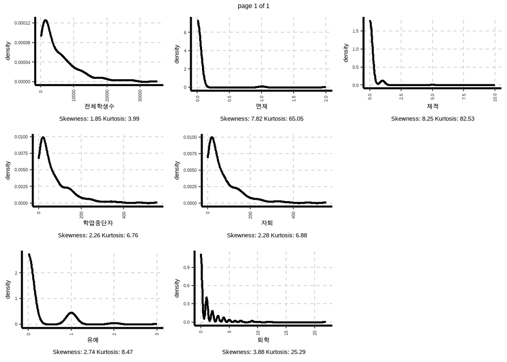

```r
plot <- df_dropout |> filter(시군 != '소계', 학교급 == '고등학교') |> ExpNumViz(Page=c(3,3))

plot
```

```
## $`0`
```

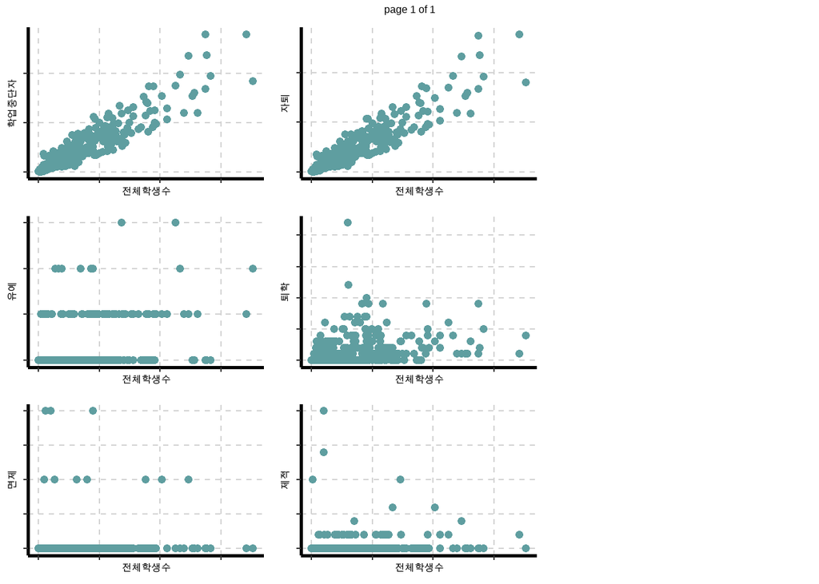

```r
plot <- df_dropout |> filter(시군 != '소계', 학교급 == '고등학교') |> ExpNumViz(Page=c(3,3), target = '전체학생수')

plot
```

### 범주형 변수 요약

```r
ExpCTable(df_dropout, Target = '시도', per = T)
```

```
##   VARIABLE CATEGORY Number 시도:강원 시도:경기 시도:경남 시도:경북 시도:광주
## 1     연도     2021     nn     144.0     276.0    166.00    197.00     57.00
## 2     연도     2022     nn     134.0     261.0    151.00    185.00     45.00
## 3     연도    TOTAL     nn     278.0     537.0    317.00    382.00    102.00
## 4     연도     2021      %      51.8      51.4     52.37     51.57     55.88
## 5     연도     2022      %      48.2      48.6     47.63     48.43     44.12
## 6     연도    TOTAL      %     100.0     100.0    100.00    100.00    100.00
##   시도:대구 시도:대전 시도:부산 시도:서울 시도:세종 시도:울산 시도:인천
## 1     87.00     58.00    149.00    243.00     20.00     53.00    103.00
## 2     74.00     47.00    134.00    230.00     10.00     42.00     89.00
## 3    161.00    105.00    283.00    473.00     30.00     95.00    192.00
## 4     54.04     55.24     52.65     51.37     66.67     55.79     53.65
## 5     45.96     44.76     47.35     48.63     33.33     44.21     46.35
## 6    100.00    100.00    100.00    100.00    100.00    100.00    100.00
##   시도:전남 시도:전북 시도:제주 시도:충남 시도:충북   TOTAL
## 1    190.00    121.00     26.00    137.00     99.00 2126.00
## 2    180.00    110.00     17.00    124.00     88.00 1921.00
## 3    370.00    231.00     43.00    261.00    187.00 4047.00
## 4     51.35     52.38     60.47     52.49     52.94   52.53
## 5     48.65     47.62     39.53     47.51     47.06   47.47
## 6    100.00    100.00    100.00    100.00    100.00  100.00
```

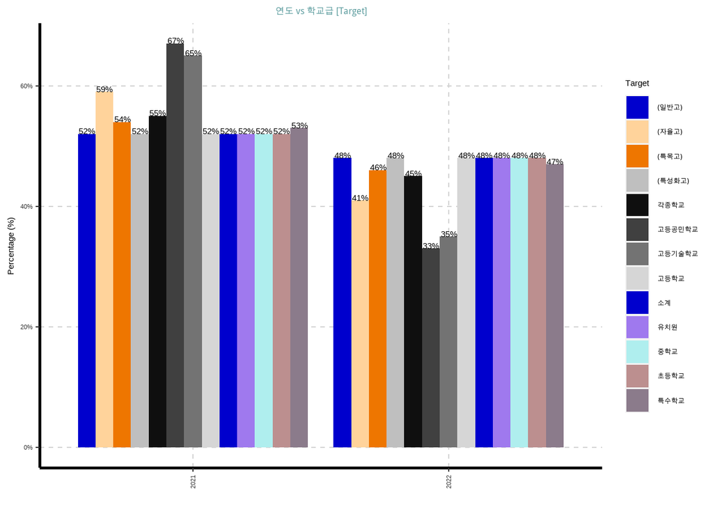

```r
plot2 <- ExpCatViz(df_dropout,target='학교급')
plot2[[1]]
```